# Modeling Seasonality

JEN-WEN LIN

April 6, 2016

```r
library(forecast)
library(pear)
```

## Commonly used time series models for seasonality

### 1. STL:

The Seasonal-Trend Decomposition Procedure Based on Loess (STL) of [Cleveland et al. (1990)](http://www.wessa.net/download/stl.pdf) is widely used by statisticans and econometricians to capture the trend and seasonal components in time series.

### 2. SARIMA

The Box-Jenkins approach is one of the most popular methods for studying time series. This approach formulates seasonal time series as [Seasonal Autoregressive and Moving Average model (SARIMA) models](http://www.stats.uwo.ca/faculty/aim/1994Book/1994-Time-chapter%2012.pdf), which rely on seasonal differencing to take into account seasonal effects. Do not confuse with [Periodic time series models](http://www.stats.uwo.ca/faculty/aim/1994Book/1994-Time-chapter%2014.pdf), which considers different parameterization of ARMA models at different periods.

### 3. Structural time series models

The [structural time series model](http://www.stat.yale.edu/~lc436/papers/Harvey_Peters1990.pdf) formulates time series directly in terms of the traditional components of trend, seasonal, cycle and irregular. The attraction of such a formulation is that it has an immediate interpretation and so is a natural vehicle for making forecasts. Moreover, it is easy to incorporate explanatory variables of interest into a structural time series model and estimate it using the Kalman filter. Therefore, the use of structural time series models has become a main stream in morden econometrics and widely used in forecasting macroeconomic variables.

### 4. Holt-Winters exponential smoothing:

The [Holt-Winters exponential smoothing method](https://forecasters.org/pdfs/foresight/free/Issue19_goodwin.pdf) has been proposed for more than 50 years and still been used in many business forecasting exercises.

#### 1. Simple exponential smoothing:

Let $Y_t(1)$ denotes the one-step ahead forecast at time $t$. Brown (1959) suggests a forecast scheme based on the forecast for the previous period and adjusting it using the forecast errors. That is,
$$Y_t(1)=Y_{t-1}(1)+\alpha (Y_t-Y_{t-1}(1)),$$
where $0<\alpha<1$. We can also express the above equation as
$$Y_t(1)=\alpha Y_t + (1-\alpha) Y_{t-1}(1).$$
The forecast $Y_t(1)$ is based on weighting the most recent observation $Y_t$ with a weight value $\alpha$ and weighting the most recent forecast $Y_{t-1}(1)$ with a weight of $1-\alpha$.

#### 2. Holt linear method:

1. Level:
   $$l_t = \alpha Y_t + (1-\alpha) (l_{t-1}+b_{t-1})$$
2. Trend:
   $$b_t = \beta (l_t-l_{t-1}) +(1-\beta) b_{t-1}$$
3. Forecast:
   $$y_t(h)=l_t+b_t h$$

#### 2. Holt-Winters’ linear and seasonality method:

1. Level:
   $$l_t = \alpha (Y_t-Y_{t-m}) + (1-\alpha) (l_{t-1}+b_{t-1})$$
2. Trend:
   $$b_t = \beta (l_t-l_{t-1}) +(1-\beta) b_{t-1}$$
3. Seasonal:
   $$s_t = \gamma (Y_t-l_{t-1}-b_{t-1})+(1-\gamma) s_{t-m}$$
4. Forecast:
   $$y_t(h)=l_t+b_t h+s_{t-m+h}$$

##### Remark: [Hyndman (2002)](http://www.diku.dk/hjemmesider/ansatte/pisinger/production/ForecastingBasedOnStateSpaceModelsForExponentialSmoothing.pdf) provides a good summary of various exponential smoothing models and their connection with state-space models.

## Examples

### 1. Data: Monthly Airline Passenger Numbers 1949-1960

```r
head(AirPassengers)
```

```
## [1] 112 118 132 129 121 135
```

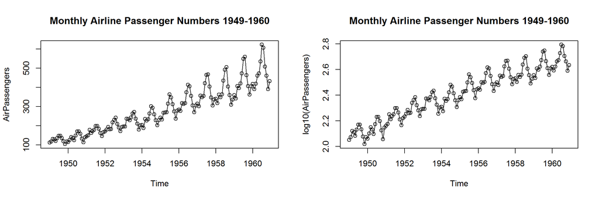

```r
par(mfrow=c(1,2))
plot(AirPassengers,type="o", main="Monthly Airline Passenger Numbers 1949-1960")
plot(log10(AirPassengers),type="o", main="Monthly Airline Passenger Numbers 1949-1960")
```

```r
air<-ts(log10(AirPassengers),start=c(1949,1),freq=12)
```

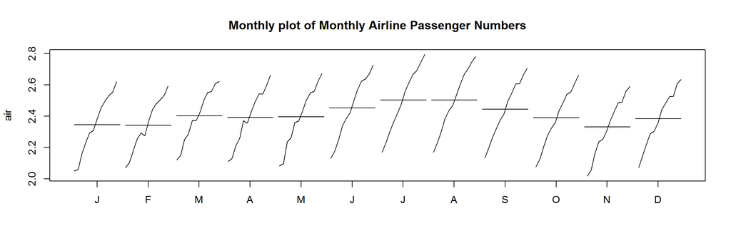

```r
monthplot(air,main="Monthly plot of Monthly Airline Passenger Numbers", type="l")
```

### 2. STL

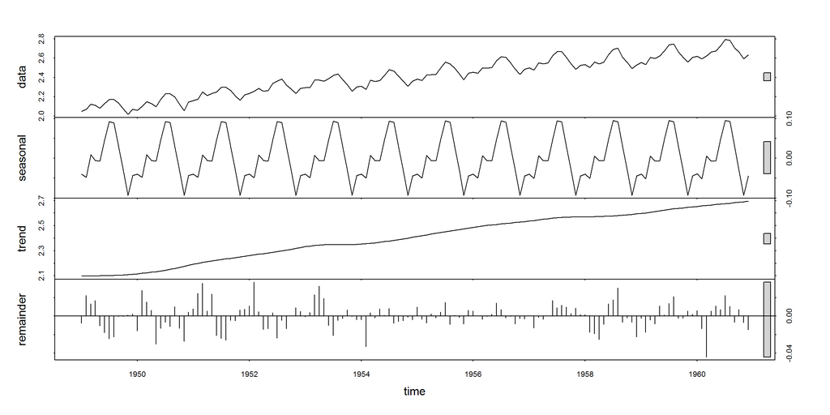

```r
par(mfrow=c(1,2))
plot(stl(air,s.window=35))
```

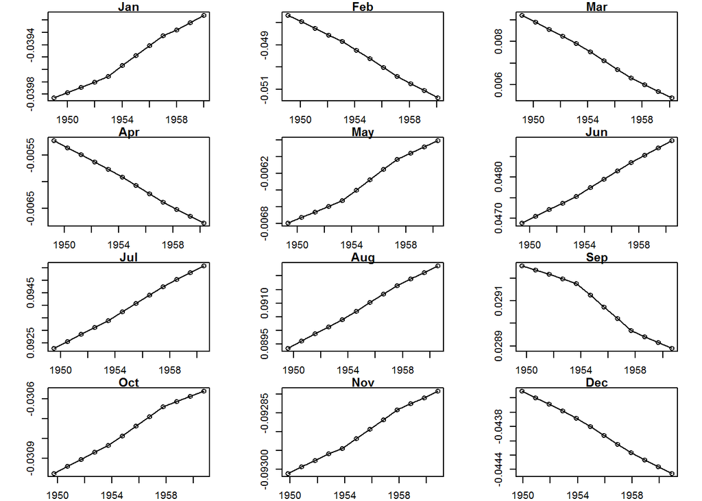

```r
par(mfrow=c(4,3),mar=c(2,4,1,2),cex=0.6)
for(mon in month.abb) {
        plot(subset(stl(air,s.window=35)$time.series[,1],month =mon),type="o",main=mon,ylab=NA)
        abline(h=0,col=2,lty="dashed")
}
```

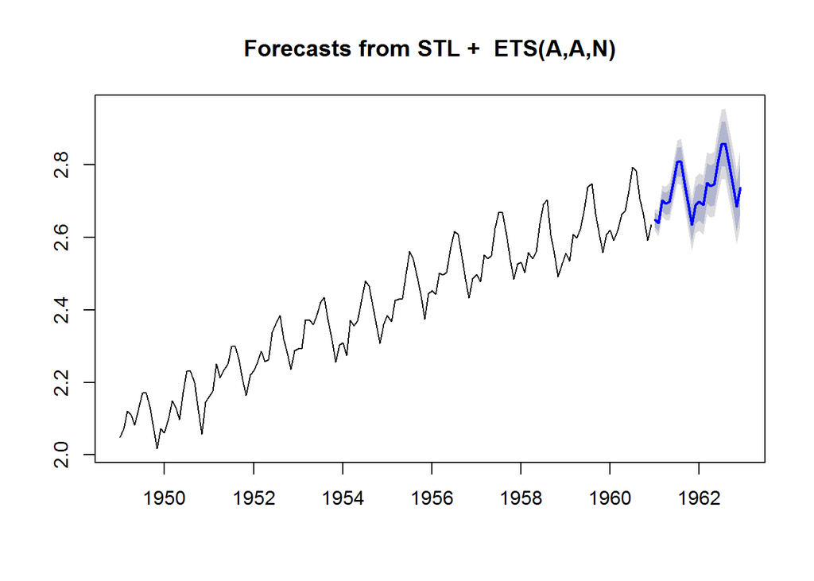

```r
plot(forecast(stl(air,s.window=35)))
```

### 2. SARIMA and periodic time series models

```r
mod.sarima<-auto.arima(air)
summary(mod.sarima)
```

```
## Series: air
## ARIMA(0,1,1)(0,1,1)[12]
##
## Coefficients:
##           ma1     sma1
##       -0.4018  -0.5569
## s.e.   0.0896   0.0731
##
## sigma^2 estimated as 0.0002586:  log likelihood=353.96
## AIC=-701.92   AICc=-701.73   BIC=-693.29
##
## Training set error measures:
##                        ME       RMSE        MAE        MPE      MAPE
## Training set 0.0002488778 0.01522151 0.01140472 0.01098898 0.4752815
##                   MASE      ACF1
## Training set 0.2169522 0.0144393
```

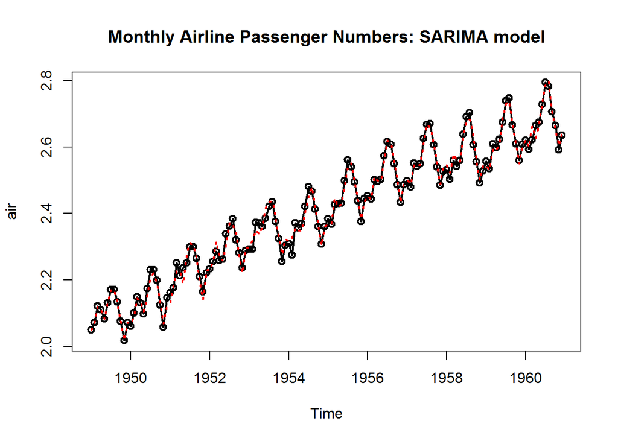

```r
ts.plot(air,type="o",lwd=2, main="Monthly Airline Passenger Numbers: SARIMA model")
lines(fitted(mod.sarima),col=2,lwd=2,lty="dotted")
```

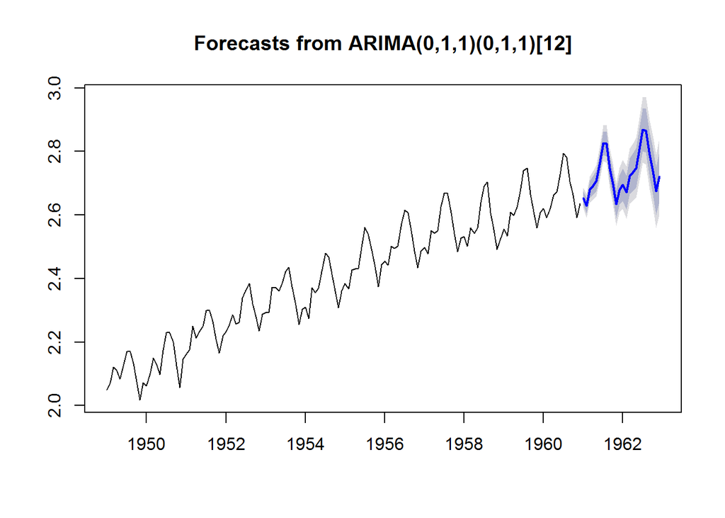

```r
plot(forecast(mod.sarima))
```

#### Remark: Two r packages for modeling period time series:

##### 1. [periodic autoregressive model](https://cran.r-project.org/web/packages/pear/pear.pdf).

##### 2. [periodic arma model](https://cran.r-project.org/web/packages/perARMA/perARMA.pdf).

### 3. Structural time series models

Many r packages implment structural time series models, such as [dlm](https://cran.r-project.org/web/packages/dlm/dlm.pdf) and [bsts](https://cran.r-project.org/web/packages/bsts/bsts.pdf). [Fernando Tusell (2011)](https://www.jstatsoft.org/article/view/v039i02) provides a detailed discussion of different R package.

### 4. Holt-Winters exponential smoothing models

```r
fit<-HoltWinters(air)
fit[c("alpha","beta","gamma")]
```

```
## $alpha
##    alpha
## 0.326612
##
## $beta
##        beta
## 0.005744246
##
## $gamma
##     gamma
## 0.8207255
```

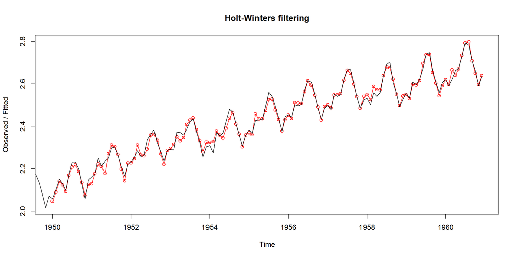

```r
plot(fit,type="o")
```

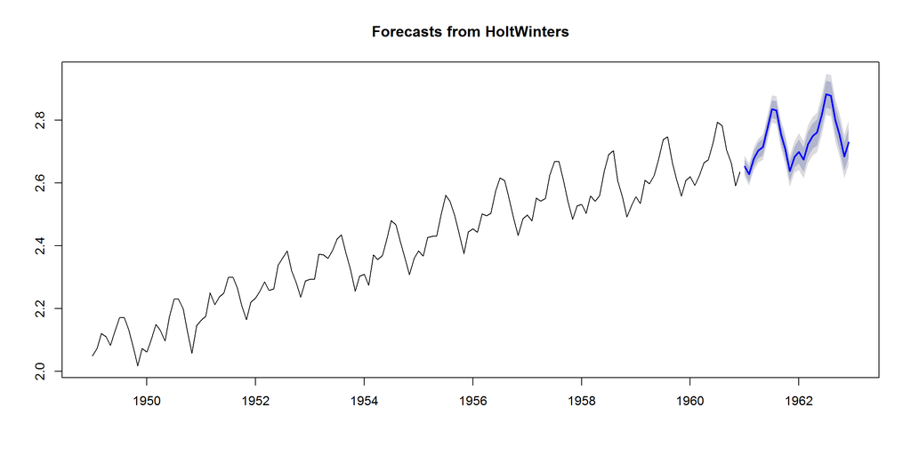

```r
plot(forecast(fit))
```